# Stats 506 Problem Set 4

Author

Honghao Wang

GitHub Repo: https://github.com/whonghao-code/stats506/tree/main

## **Problem 1**

(a) The table shows the total votes for each year and voting type, sorted from highest to lowest.

```r
library(tidyverse)
library(nzelect)

ans_1a <- nzge %>%
  group_by(election_year, voting_type) %>%
  summarise(total_votes = sum(votes, na.rm = TRUE), .groups = "drop") %>%
  arrange(desc(total_votes))

print(ans_1a)
```

```
# A tibble: 12 × 3
   election_year voting_type total_votes
           <dbl> <chr>             <dbl>
 1          2017 Party           2602689
 2          2017 Candidate       2560085
 3          2014 Party           2416479
 4          2014 Candidate       2375493
 5          2008 Party           2356536
 6          2008 Candidate       2325598
 7          2005 Party           2286190
 8          2005 Candidate       2260670
 9          2011 Party           2257336
10          2011 Candidate       2225766
11          2002 Party           2040248
12          2002 Candidate       2022115
```

(b) This table shows the 2014 Candidate election results.

```r
ans_1b <- nzge %>%
  filter(election_year == "2014", voting_type == "Candidate") %>%
  group_by(party) %>%
  summarise(party_votes = sum(votes, na.rm = TRUE), .groups = "drop") %>%
  mutate(percent_vote = (party_votes / sum(party_votes)) * 100) %>%
  arrange(desc(percent_vote))

print(ans_1b)
```

```
# A tibble: 25 × 3
   party                    party_votes percent_vote
   <chr>                          <dbl>        <dbl>
 1 National Party               1081787       45.5
 2 Labour Party                  801287       33.7
 3 Green Party                   165718        6.98
 4 Conservative Party             81075        3.41
 5 New Zealand First Party        73384        3.09
 6 Maori Party                    42108        1.77
 7 MANA Movement                  32333        1.36
 8 Informal Candidate Votes       27886        1.17
 9 ACT New Zealand                27778        1.17
10 United Future                  14722        0.620
# ℹ 15 more rows
```

(c) This table shows which party won each year.

```r
ans_1c <- nzge %>%
  group_by(election_year, voting_type, party) %>%
  summarise(total_votes = sum(votes, na.rm = TRUE), .groups = "drop") %>%
  group_by(election_year, voting_type) %>%
  slice_max(order_by = total_votes, n = 1) %>%
  select(election_year, voting_type, party) %>%
  pivot_wider(names_from = voting_type, values_from = party)

print(ans_1c)
```

```
# A tibble: 6 × 3
# Groups:   election_year [6]
  election_year Candidate      Party
          <dbl> <chr>          <chr>
1          2002 Labour Party   Labour Party
2          2005 National Party Labour Party
3          2008 National Party National Party
4          2011 National Party National Party
5          2014 National Party National Party
6          2017 National Party National Party
```

## **Problem 2**

(a) There were 128 tournaments in 2019.

```r
tennis <- read_csv("atp_matches_2019.csv")
ans_2a <- tennis %>%
  summarise(num_tournaments = n_distinct(tourney_id))
print(ans_2a)
```

```
# A tibble: 1 × 1
  num_tournaments
            <int>
1             128
```

(b) Yes, 12 players won more than one tournament. The most winning players were Dominic Thiem and Novak Djokovic, who both won 5 tournaments.

```r
tournament_winners <- tennis %>%
  filter(round == "F") %>%
  count(winner_name, name = "tournaments_won")

multiple_winners_count <- tournament_winners %>%
  filter(tournaments_won > 1) %>%
  nrow()

max_wins <- tournament_winners %>%
  slice_max(tournaments_won, n = 1)

cat("Number of players who won >1 tournament:", multiple_winners_count, "\n")
```

```
Number of players who won >1 tournament: 12
```

```r
print(max_wins)
```

```
# A tibble: 2 × 2
  winner_name    tournaments_won
  <chr>                    <int>
1 Dominic Thiem                5
2 Novak Djokovic               5
```

(c) Yes, there is evidence. On average, winners had 7.50 aces per match while losers had 5.79. Furthermore, the winner had more aces than the loser in 57.3% of the matches.

```r
ans_2c <- tennis %>%
  select(w_ace, l_ace) %>%
  drop_na() %>%
  summarise(
    mean_winner_aces = mean(w_ace),
    mean_loser_aces = mean(l_ace),
    matches_evaluated = n(),
    winner_had_more = sum(w_ace > l_ace),
    percent_winner_more = (winner_had_more / matches_evaluated) * 100
  )
print(ans_2c)
```

```
# A tibble: 1 × 5
  mean_winner_aces mean_loser_aces matches_evaluated winner_had_more
             <dbl>           <dbl>             <int>           <int>
1             7.50            5.79              2694            1543
# ℹ 1 more variable: percent_winner_more <dbl>
```

(d) Rafael Nadal had the highest win-rate among players with at least 5 matches. He won 60 out of 69 matches, giving him a win-rate of 87.0%

```r
wins <- tennis %>% count(winner_name, name = "wins")
losses <- tennis %>% count(loser_name, name = "losses")

ans_2d <- wins %>%
  full_join(losses, by = c("winner_name" = "loser_name")) %>%
  rename(player = winner_name) %>%
  replace_na(list(wins = 0, losses = 0)) %>%
  mutate(
    total_matches = wins + losses,
    win_rate = wins / total_matches
  ) %>%
  filter(total_matches >= 5) %>%
  arrange(desc(win_rate)) %>%
  slice_max(win_rate, n = 1)

print(ans_2d)
```

```
# A tibble: 1 × 5
  player        wins losses total_matches win_rate
  <chr>        <int>  <int>         <int>    <dbl>
1 Rafael Nadal    60      9            69    0.870
```

## **Problem 3**

(a) Based on the plot, there is one massive major spike in early 2022. There are also about three or four minor spikes occurring around early 2021, late 2021, and mid-2022.

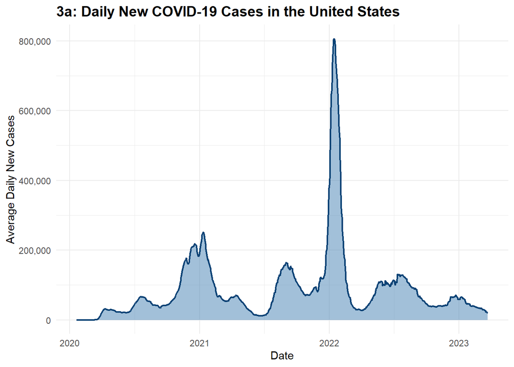

```r
library(lubridate)
url <- "https://raw.githubusercontent.com/nytimes/covid-19-data/refs/heads/master/rolling-averages/us-states.csv"
covid_data <- read_csv(url)
us_totals <- covid_data %>%
  group_by(date) %>%
  summarise(total_cases_avg = sum(cases_avg, na.rm = TRUE))

plot_a <- ggplot(us_totals, aes(x = date, y = total_cases_avg)) +
  geom_area(fill = "steelblue", alpha = 0.5) +
  geom_line(color = "#0B4275", size = 0.8) +
  scale_y_continuous(labels = scales::comma) +
  labs(title = "3a: Daily New COVID-19 Cases in the United States",
       x = "Date",
       y = "Average Daily New Cases") +
  theme_minimal() +
  theme(plot.title = element_text(face = "bold", size = 14))
print(plot_a)
```

(b) The plot compares the states with the highest and lowest overall rates. The highest rate states (Rhode Island and American Samoa) show very sharp, extreme spikes, reaching over 400 daily cases per 100k. In contrast, the lowest rate states (Maine and Maryland) have much flatter curves with much lower peaks over time.

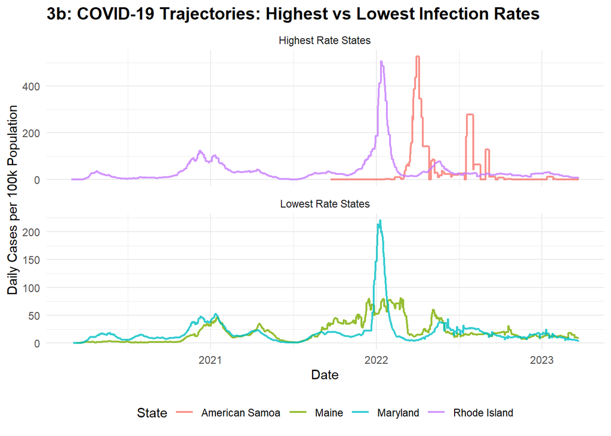

```r
overall_rates <- covid_data %>%
  group_by(state) %>%
  summarise(mean_rate = mean(cases_avg_per_100k, na.rm = TRUE))

top_states <- overall_rates %>% slice_max(mean_rate, n = 2) %>% pull(state)
bottom_states <- overall_rates %>% slice_min(mean_rate, n = 2) %>% pull(state)
target_states <- c(top_states, bottom_states)

plot_b <- covid_data %>%
  filter(state %in% target_states) %>%
  mutate(Status = ifelse(state %in% top_states, "Highest Rate States", "Lowest Rate States")) %>%
  ggplot(aes(x = date, y = cases_avg_per_100k, color = state)) +
  geom_line(size = 0.8, alpha = 0.8) +
  facet_wrap(~Status, ncol = 1, scales = "free_y") +
  labs(title = "3b: COVID-19 Trajectories: Highest vs Lowest Infection Rates",
       x = "Date",
       y = "Daily Cases per 100k Population",
       color = "State") +
  theme_minimal() +
  theme(plot.title = element_text(face = "bold", size = 14),
        legend.position = "bottom")

print(plot_b)
```

(c) By defining a “substantial” outbreak as reaching 5 daily cases per 100k population, the first five states to hit this mark were Connecticut, Louisiana, Massachusetts, New Jersey, and New York. The graph shows their case rates shooting up very quickly between March and April 2020.

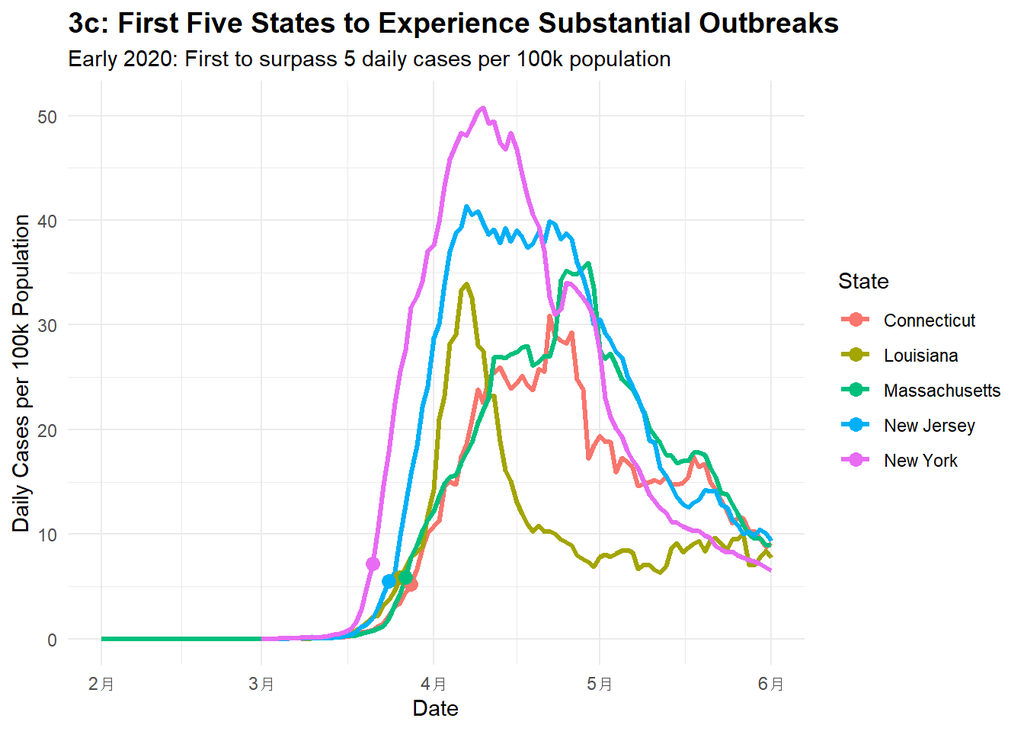

```r
first_substantial <- covid_data %>%
  filter(cases_avg_per_100k >= 5) %>%
  group_by(state) %>%
  summarise(first_date = min(date)) %>%
  arrange(first_date) %>%
  slice_head(n = 5) %>%
  pull(state)

plot_c <- covid_data %>%
  filter(state %in% first_substantial, date <= as.Date("2020-06-01")) %>%
  ggplot(aes(x = date, y = cases_avg_per_100k, color = state)) +
  geom_line(size = 1.2) +
  geom_point(data = . %>% filter(cases_avg_per_100k >= 5) %>% group_by(state) %>% slice_head(n=1),
             size = 3) +
  labs(title = "3c: First Five States to Experience Substantial Outbreaks",
       subtitle = "Early 2020: First to surpass 5 daily cases per 100k population",
       x = "Date",
       y = "Daily Cases per 100k Population",
       color = "State") +
  theme_minimal() +
  theme(plot.title = element_text(face = "bold", size = 14))

print(plot_c)
```